# Stats & Data Science II - Assignment

# Problem description

In our cities, there are some services that are essential for our daily living: pharmacies, schools or transport points of sale. However, these facilities are not necessarily well distributed. We want to analyze in this assignment which areas lacks of these facilities based on regression models. The steps to perform the analysis are:

- EDA: Descriptive analysis of data
- Feature selection: Are there variables we can discard?
- Perform a feature engineering process extending important variables
- Perform regression modelling for the three target variables (three different models).
- Create a score to measure which areas have enough facilities and which ones don’t.
- Which variables are the most highly related to the score? In particular, what makes a census section to have a low number of facilities?
- Discuss the results

# Dataset description

```r
df<-fread("census_section_stats.csv", sep=";", dec=",", stringsAsFactors = F)
```

For every census section we have a row in our dataset, here are some of the main columns of the dataset:

- census_section_code: census_section_code identifier
- n_pharmacies (target variable 1): number of pharmacies in the census section
- n_schools (target variable 2): number of schools in the census section
- n_transport_salespoints (target variable 3): number of transport points of sale.

# Libraries

```r
library(DataExplorer)
library(corrplot)
library(glmnet)
library(MASS)
library(pscl)
library(pROC)
library(caret)
library(tidyverse)
```

# Descriptive analysis

## Pre-processing

```r
df <- as_tibble(df)

summary(df)
```

```
##      index      census_section_code  census_district_code   city_code
##  Min.   :   0   Min.   :2800101001   Min.   :2800101      Min.   :28001
##  1st Qu.:1103   1st Qu.:2807901027   1st Qu.:2807901      1st Qu.:28079
##  Median :2206   Median :2807910084   Median :2807910      Median :28079
##  Mean   :2206   Mean   :2808267820   Mean   :2808268      Mean   :28083
##  3rd Qu.:3310   3rd Qu.:2807918047   3rd Qu.:2807918      3rd Qu.:28079
##  Max.   :4413   Max.   :2890301025   Max.   :2890301      Max.   :28903
##  province_code      area             centroid           population
##  Min.   :28    Min.   :  0.00594   Length:4414        Min.   :  47
##  1st Qu.:28    1st Qu.:  0.02962   Class :character   1st Qu.:1075
##  Median :28    Median :  0.05510   Mode  :character   Median :1381
##  Mean   :28    Mean   :  1.81802                      Mean   :1490
##  3rd Qu.:28    3rd Qu.:  0.17587                      3rd Qu.:1816
##  Max.   :28    Max.   :180.87857                      Max.   :4004
##  family_income   income_per_capita    avg_age         spanish
##  Min.   :12537   Min.   : 3719     Min.   :25.54   Min.   :0.5293
##  1st Qu.:27843   1st Qu.:10580     1st Qu.:40.26   1st Qu.:0.8267
##  Median :34315   Median :13046     Median :43.48   Median :0.8870
##  Mean   :39489   Mean   :14798     Mean   :42.81   Mean   :0.8723
##  3rd Qu.:45429   3rd Qu.:17523     3rd Qu.:46.11   3rd Qu.:0.9316
##  Max.   :91933   Max.   :32242     Max.   :65.80   Max.   :1.0000
##    foreigners        europeans          germans            bulgarian
##  Min.   :0.00000   Min.   :0.00000   Min.   :0.0000000   Min.   :0.000000
##  1st Qu.:0.06844   1st Qu.:0.02225   1st Qu.:0.0000000   1st Qu.:0.000000
##  Median :0.11302   Median :0.03463   Median :0.0005139   Median :0.001415
##  Mean   :0.12773   Mean   :0.04296   Mean   :0.0011480   Mean   :0.003190
##  3rd Qu.:0.17327   3rd Qu.:0.05170   3rd Qu.:0.0014967   3rd Qu.:0.004183
##  Max.   :0.47070   Max.   :0.37260   Max.   :0.0425532   Max.   :0.071467
##      french            italian             polish           portuguese
##  Min.   :0.000000   Min.   :0.000000   Min.   :0.000000   Min.   :0.0000000
##  1st Qu.:0.000000   1st Qu.:0.001131   1st Qu.:0.000000   1st Qu.:0.0004852
##  Median :0.000800   Median :0.002936   Median :0.001106   Median :0.0014996
##  Mean   :0.002043   Mean   :0.004480   Mean   :0.002248   Mean   :0.0022547
##  3rd Qu.:0.002249   3rd Qu.:0.005994   3rd Qu.:0.003012   3rd Qu.:0.0032338
##  Max.   :0.121133   Max.   :0.037788   Max.   :0.134831   Max.   :0.0243902
##     british             romanian        non_european         russian
##  Min.   :0.0000000   Min.   :0.00000   Min.   :0.000000   Min.   :0.0000000
##  1st Qu.:0.0000000   1st Qu.:0.00525   1st Qu.:0.001590   1st Qu.:0.0000000
##  Median :0.0006845   Median :0.01401   Median :0.003870   Median :0.0000000
##  Mean   :0.0014827   Mean   :0.02417   Mean   :0.005906   Mean   :0.0006801
```

[output cut: 64 more lines]

```
##  Max.   :100.000          Max.   :99.366                Max.   :1433.0
##  city_population   population_density    geometry          n_pharmacies
##  Min.   :     47   Min.   :     1.06   Length:4414        Min.   :0.0000
##  1st Qu.: 128256   1st Qu.:  9194.66   Class :character   1st Qu.:0.0000
##  Median :3223334   Median : 24941.68   Mode  :character   Median :1.0000
##  Mean   :1832968   Mean   : 26806.53                      Mean   :0.6613
##  3rd Qu.:3223334   3rd Qu.: 41233.71                      3rd Qu.:1.0000
##  Max.   :3223334   Max.   :113560.50                      Max.   :5.0000
##    n_schools       n_transport_salespoints pcg_foreigners
##  Min.   : 0.0000   Min.   :0.0000          Min.   : 0.000
##  1st Qu.: 0.0000   1st Qu.:0.0000          1st Qu.: 6.844
##  Median : 0.0000   Median :0.0000          Median :11.302
##  Mean   : 0.9076   Mean   :0.2707          Mean   :12.773
##  3rd Qu.: 1.0000   3rd Qu.:0.0000          3rd Qu.:17.327
##  Max.   :12.0000   Max.   :4.0000          Max.   :47.070
```

Each observation (row) is a different census section with its unique `census_section_code` as identifier. This code also carries information about the province, city and district (although they are also stored in other variables).

Then most of the variables present in the dataset are some characteristics of this section (such as population, area. income, age composition, ethnic composition), while some variables are coded at a city level (population). Lastly, we have our target variables.

None of the variables take negative values. The majority of the variables represent percentages.

```r
# We don't have any NA
any(is.na.data.frame(df))
```

```
## [1] FALSE
```

```r
# Dropping pcg_foreigners which is the same variable as foreigners
cor(df$pcg_foreigners, df$foreigners)
```

```
## [1] 1
```

```r
# Dropping province code as the variable takes only one value
unique(df$province_code)
```

```
## [1] 28
```

```r
# Dropping index which is just the row number
# Dropping geometry which is a variable that carries no information for our regressions
df <- df |>
  select(-province_code, -index, -pcg_foreigners, -geometry)

# Extracting geographic info from centroid
df <- df |>
  mutate(centroid = gsub("POINT \\(|\\)", "", centroid)) |>
  separate_wider_delim(centroid, names = c("x_coord", "y_coord"), delim = " ")
```

I drop unnecessary variables and transform `centroid` to try to use the information it carries.

```r
str(df)
```

```
## tibble [4,414 × 62] (S3: tbl_df/tbl/data.frame)
##  $ census_section_code          :integer64 [1:4414] 2807915077 2807911153 2807912045 2807912028 2807912037 2807912008 2807911155 2807911191 ...
##  $ census_district_code         : int [1:4414] 2807915 2807911 2807912 2807912 2807912 2807912 2807911 2807911 2807908 2807908 ...
##  $ city_code                    : int [1:4414] 28079 28079 28079 28079 28079 28079 28079 28079 28079 28079 ...
##  $ area                         : num [1:4414] 0.0311 0.0369 0.0317 0.0115 0.0447 ...
##  $ x_coord                      : chr [1:4414] "445950.10837580997" "435897.6843577322" "440254.6396935178" "441426.03395814047" ...
##  $ y_coord                      : chr [1:4414] "4475766.441625915" "4468991.370699024" "4470484.3928486835" "4469702.549072934" ...
##  $ population                   : int [1:4414] 1073 1578 1793 911 1324 1226 2392 2250 817 997 ...
##  $ family_income                : num [1:4414] 31418 26574 22959 22828 23078 ...
##  $ income_per_capita            : num [1:4414] 12899 10194 7426 9018 8403 ...
##  $ avg_age                      : num [1:4414] 49 44.1 38.7 46.1 43.3 ...
##  $ spanish                      : num [1:4414] 0.866 0.776 0.627 0.786 0.918 ...
##  $ foreigners                   : num [1:4414] 0.1342 0.2237 0.3731 0.2141 0.0816 ...
##  $ europeans                    : num [1:4414] 0.0317 0.0786 0.0167 0.056 0.0068 ...
##  $ germans                      : num [1:4414] 0 0 0 0 0 ...
```

[output cut: 48 more lines]

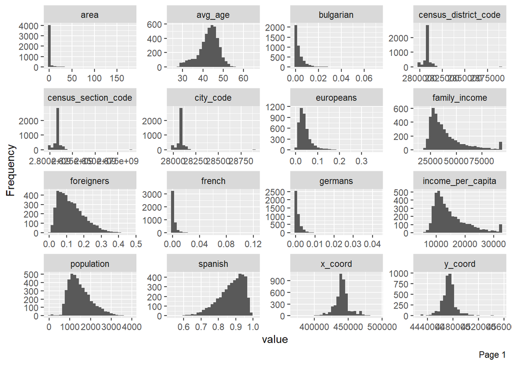

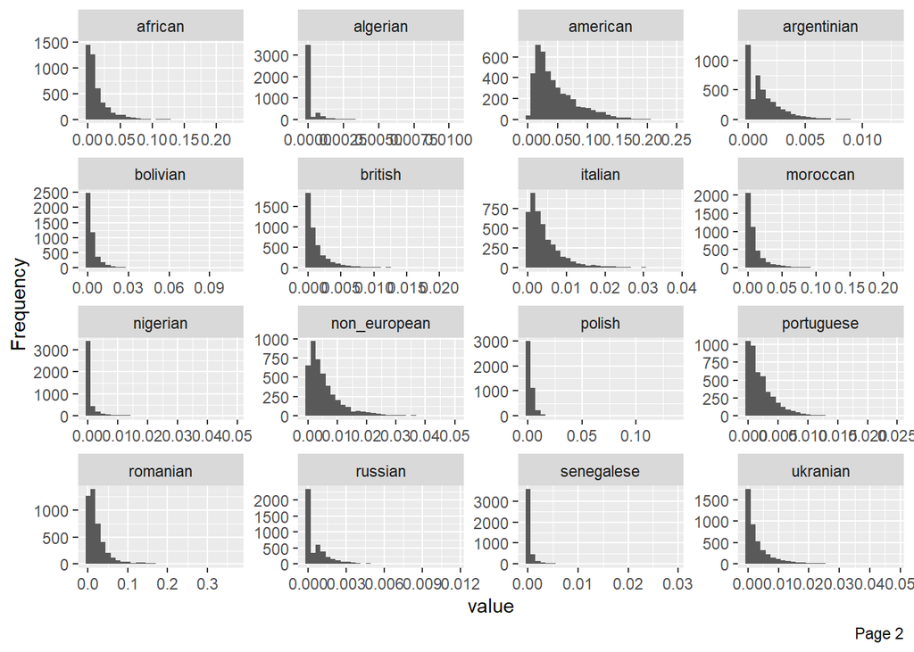

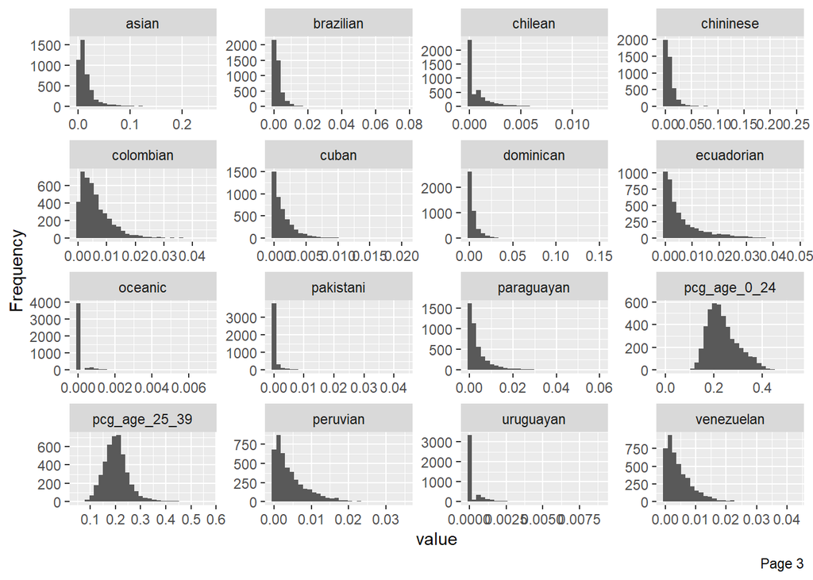

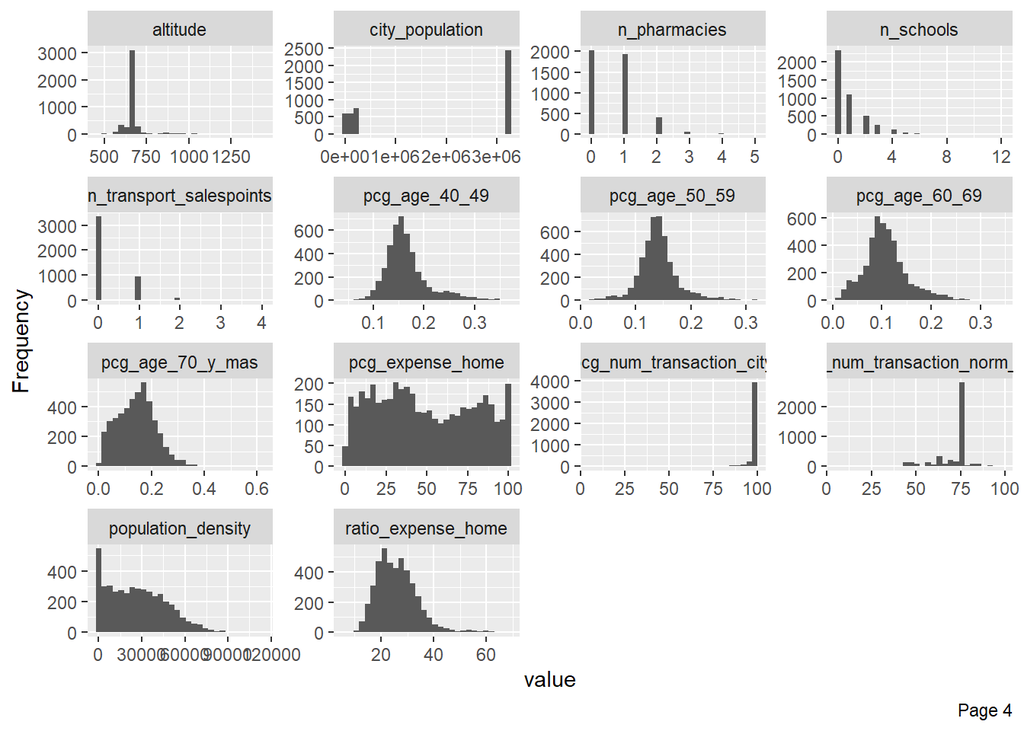

```r
# Converting to numeric
df <- df |>
  mutate(across(everything(), as.numeric))

plot_histogram(df[names(df)])
```

From the histograms we can see that most of the variables are not normally distributed. Most of them (especially the percentages) are right skewed and for many of them, 0 or values close to 0 are the most present values.

## Independent variables

```r
# Exploring multicollinearity of independent variables
corrplot(cor(df |> select(- n_pharmacies, - n_schools, - n_transport_salespoints)), type = "upper", method = "circle", tl.cex = 0.5, tl.col = "black", order = "FPC")
```

[figure not shown]

From this first graph we cannot understand much due to the high number of variables present. However, we can already see that there are cases of highly correlated variables. For example, `spanish` is highly correlated with other variables storing other ethnic compositions.

```r
corr_simple <- function(data=df,sig=0.5){
  #run a correlation and drop the insignificant ones
  corr <- cor(df)
  #prepare to drop duplicates and correlations of 1
  corr[lower.tri(corr,diag=TRUE)] <- NA
  #turn into a 3-column table
  corr <- as.data.frame(as.table(corr))
  #remove the NA values from above
  corr <- na.omit(corr)
  #rename Freq to Correlation
  names(corr)[names(corr) == "Freq"] <- "Correlation"
  #select significant values
  corr <- subset(corr, abs(Correlation) > sig)
  #sort by highest correlation
  corr <- corr[order(-abs(corr$Correlation)),]
  #print values above 0.9
  print(corr[abs(corr$Correlation) > 0.9, ])
  #turn corr back into matrix in order to plot with corrplot
  mtx_corr <- reshape2::acast(corr, Var1~Var2, value.var="Correlation")
  #plot correlations visually
  corrplot(mtx_corr, is.corr=FALSE, tl.col="black", na.label=" ", tl.cex = 0.7)
}
corr_simple(df |> select(- n_pharmacies, - n_schools, - n_transport_salespoints))
```

```
##                      Var1                 Var2 Correlation
## 693               spanish           foreigners  -1.0000000
## 63    census_section_code census_district_code   1.0000000
## 126  census_district_code            city_code   0.9999997
## 125   census_section_code            city_code   0.9999997
## 1637              african             moroccan   0.9457789
## 504         family_income    income_per_capita   0.9372583
## 1448         non_european             ukranian   0.9184232
## 1253            europeans             romanian   0.9097788
## 3172              avg_age     pcg_age_70_y_mas   0.9083057
```

[figure not shown]

Using a function I have found on the internet, I extract only the strongest correlation to have a closer look at them (plotted are the ones above |0.5| and printed are the ones above |0.9|). We see that some of our explanatory variables are highly correlated among each other.

The location codes are highly correlated among each other as the information of the larger geographical level is included in the lower geographical level. `family_income` is highly correlated with `income_per_capita` as conceivable. The ethnic composition percentages are highly correlated among themselves as they are indeed percentages of the same whole. The same happens for the percentage of different age groups,

```r
summary(lm(spanish ~ foreigners, data = df))
```

```
##
## Call:
## lm(formula = spanish ~ foreigners, data = df)
##
## Residuals:
##        Min         1Q     Median         3Q        Max
## -5.084e-08 -6.110e-10 -3.360e-10  7.000e-12  4.947e-08
##
## Coefficients:
##               Estimate Std. Error    t value Pr(>|t|)
## (Intercept)  1.000e+00  4.257e-10 2349190686   <2e-16 ***
## foreigners  -1.000e+00  2.874e-09 -347983455   <2e-16 ***
## ---
## Signif. codes:  0 '***' 0.001 '**' 0.01 '*' 0.05 '.' 0.1 ' ' 1
##
## Residual standard error: 1.432e-08 on 4412 degrees of freedom
## Multiple R-squared:      1,  Adjusted R-squared:      1
## F-statistic: 1.211e+17 on 1 and 4412 DF,  p-value: < 2.2e-16
```

```r
summary(lm(foreigners ~ europeans + non_european + african + american + asian + oceanic, data = df))
```

```
##
## Call:
## lm(formula = foreigners ~ europeans + non_european + african +
##     american + asian + oceanic, data = df)
##
## Residuals:
##        Min         1Q     Median         3Q        Max
## -9.118e-08 -2.083e-09 -4.030e-10  2.313e-09  9.622e-08
##
## Coefficients:
##               Estimate Std. Error   t value Pr(>|t|)
## (Intercept)  8.435e-10  5.864e-10 1.439e+00     0.15
## europeans    1.000e+00  8.387e-09 1.192e+08   <2e-16 ***
## non_european 1.000e+00  4.680e-08 2.137e+07   <2e-16 ***
## african      1.000e+00  1.386e-08 7.214e+07   <2e-16 ***
## american     1.000e+00  9.367e-09 1.068e+08   <2e-16 ***
## asian        1.000e+00  1.614e-08 6.197e+07   <2e-16 ***
## oceanic      1.000e+00  7.148e-07 1.399e+06   <2e-16 ***
## ---
## Signif. codes:  0 '***' 0.001 '**' 0.01 '*' 0.05 '.' 0.1 ' ' 1
##
## Residual standard error: 1.896e-08 on 4407 degrees of freedom
## Multiple R-squared:      1,  Adjusted R-squared:      1
## F-statistic: 1.152e+16 on 6 and 4407 DF,  p-value: < 2.2e-16
```

```r
summary(lm(europeans ~ germans + bulgarian + french + italian + polish + portuguese + british + romanian, data = df))
```

```
##
## Call:
## lm(formula = europeans ~ germans + bulgarian + french + italian +
##     polish + portuguese + british + romanian, data = df)
##
## Residuals:
##        Min         1Q     Median         3Q        Max
## -0.0100702 -0.0008875 -0.0003298  0.0006449  0.0121565
##
## Coefficients:
##              Estimate Std. Error  t value Pr(>|t|)
## (Intercept) 4.317e-04  4.913e-05    8.787   <2e-16 ***
## germans     1.227e+00  1.559e-02   78.710   <2e-16 ***
## bulgarian   9.964e-01  5.145e-03  193.670   <2e-16 ***
## french      1.100e+00  7.094e-03  155.095   <2e-16 ***
## italian     1.082e+00  6.883e-03  157.222   <2e-16 ***
## polish      1.003e+00  6.933e-03  144.615   <2e-16 ***
## portuguese  1.087e+00  1.103e-02   98.623   <2e-16 ***
## british     1.355e+00  1.446e-02   93.682   <2e-16 ***
## romanian    9.983e-01  8.135e-04 1227.205   <2e-16 ***
## ---
## Signif. codes:  0 '***' 0.001 '**' 0.01 '*' 0.05 '.' 0.1 ' ' 1
##
## Residual standard error: 0.001711 on 4405 degrees of freedom
## Multiple R-squared:  0.9976, Adjusted R-squared:  0.9976
## F-statistic: 2.316e+05 on 8 and 4405 DF,  p-value: < 2.2e-16
```

```r
summary(lm(pcg_age_0_24 ~ pcg_age_25_39 + pcg_age_40_49 + pcg_age_50_59 + pcg_age_60_69 + pcg_age_70_y_mas, data = df))
```

```
##
## Call:
## lm(formula = pcg_age_0_24 ~ pcg_age_25_39 + pcg_age_40_49 + pcg_age_50_59 +
##     pcg_age_60_69 + pcg_age_70_y_mas, data = df)
##
## Residuals:
##        Min         1Q     Median         3Q        Max
## -2.030e-07 -3.109e-09 -8.830e-10  2.229e-09  2.002e-07
##
## Coefficients:
##                    Estimate Std. Error   t value Pr(>|t|)
## (Intercept)       1.000e+00  1.689e-08  59220809   <2e-16 ***
## pcg_age_25_39    -1.000e+00  1.995e-08 -50124747   <2e-16 ***
## pcg_age_40_49    -1.000e+00  3.833e-08 -26088145   <2e-16 ***
## pcg_age_50_59    -1.000e+00  3.129e-08 -31954276   <2e-16 ***
## pcg_age_60_69    -1.000e+00  2.583e-08 -38712641   <2e-16 ***
## pcg_age_70_y_mas -1.000e+00  1.664e-08 -60096268   <2e-16 ***
## ---
## Signif. codes:  0 '***' 0.001 '**' 0.01 '*' 0.05 '.' 0.1 ' ' 1
##
## Residual standard error: 4.768e-08 on 4408 degrees of freedom
## Multiple R-squared:      1,  Adjusted R-squared:      1
## F-statistic: 1.53e+15 on 5 and 4408 DF,  p-value: < 2.2e-16
```

```r
# Other variables which are composite
# summary(lm(non_european ~ russian + ukranian, data = df))
# summary(lm(african ~ algerian + moroccan + nigerian + senegalese, data = df))
# summary(lm(american ~ argentinian + bolivian + brazilian + colombian + cuban + chilean + ecuadorian + paraguayan + peruvian + uruguayan + venezuelan + dominican, data = df))
# summary(lm(asian ~ chininese + pakistani, data = df))
# summary(lm(avg_age ~ pcg_age_0_24 + pcg_age_25_39 + pcg_age_40_49 + pcg_age_50_59 + pcg_age_60_69 + pcg_age_70_y_mas, data = df))
```

Since I suspected that some of the explanatory variables are composite of other independent variables I run some regression to confirm my hypothesis. I found that many of my explanatory variables are indeed a linear combination of other variables (we can see it from the R-squared equal or very very close to 1). `foreigners` for example is equal to 1-`spanish` and the same happens for other ethnic composition variables such as `europeans`, `americans` etc. as well as the percentages of age groups.

As our model is a predictive and not an explanatory model, we are more focused on the performance of our model, rather than the interpretation of the coefficients. Therefore, we keep all the composite and the highly multicollinear variables without removing any of them. However in the case that we were interested in interpreting the coefficients we would have to carefully remove some of the layers of our variables.

## Dependent variables

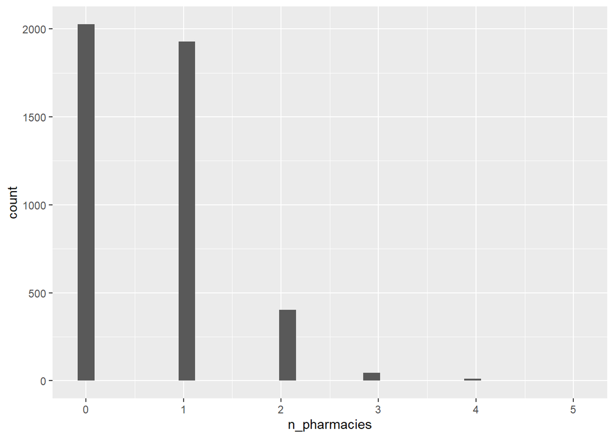

```r
# Exploring our dependent variables
ggplot(df, aes(x=n_pharmacies)) +
  geom_histogram()
```

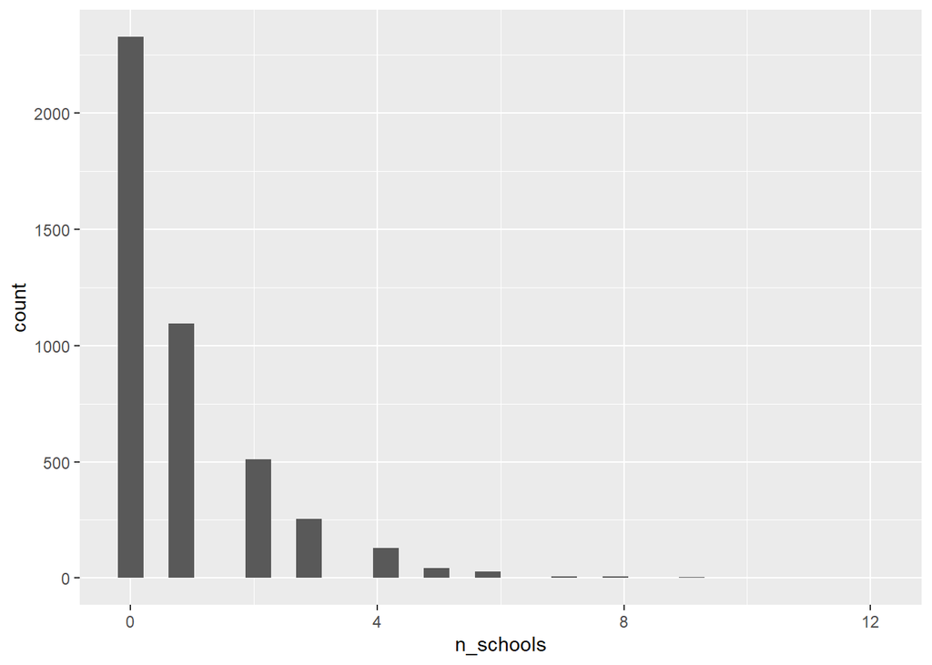

```r
ggplot(df, aes(x=n_schools)) +
  geom_histogram()
```

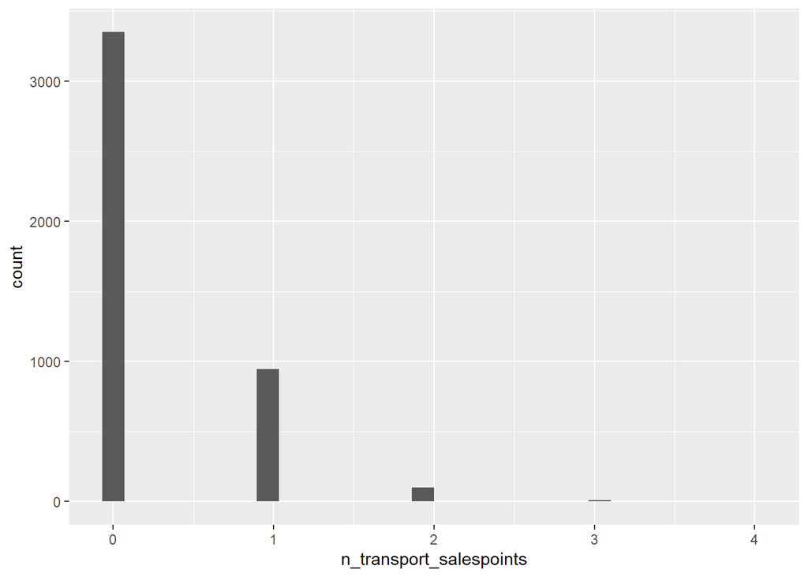

```r
ggplot(df, aes(x=n_transport_salespoints)) +
  geom_histogram()
```

Our dependent variables only take non-negatve, integer values therefore suggesting that they could be following a Poisson distribution and that Poisson regression or its variations could be a good idea for our regression models. It is also worth nothing that all our dependent variables have a high number of zeros.

```r
var(df$n_pharmacies)/mean(df$n_pharmacies)
```

```
## [1] 0.7609298
```

```r
var(df$n_schools)/mean(df$n_schools)
```

```
## [1] 1.980051
```

```r
var(df$n_transport_salespoints)/mean(df$n_transport_salespoints)
```

```
## [1] 0.9805387
```

Since we suspect our dependent variables are Poisson distributed we check whether their variance actually equals their mean (equidispersion assumption). The only dependent variable for which there seems to be a more significant difference is `n_schhols`

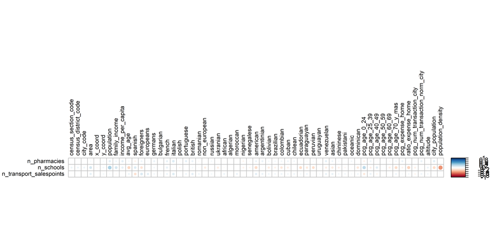

```r
# Looking at correlation between dependent and independent variables
cor_matrix <- cor(df[, !names(df) %in% c("n_pharmacies", "n_schools", "n_transport_salespoints")],
                  df[, c("n_pharmacies", "n_schools", "n_transport_salespoints")])
cor_matrix <- t(cor_matrix)
corrplot(cor_matrix, method = "circle", tl.cex = 0.7, tl.col = "black")
```

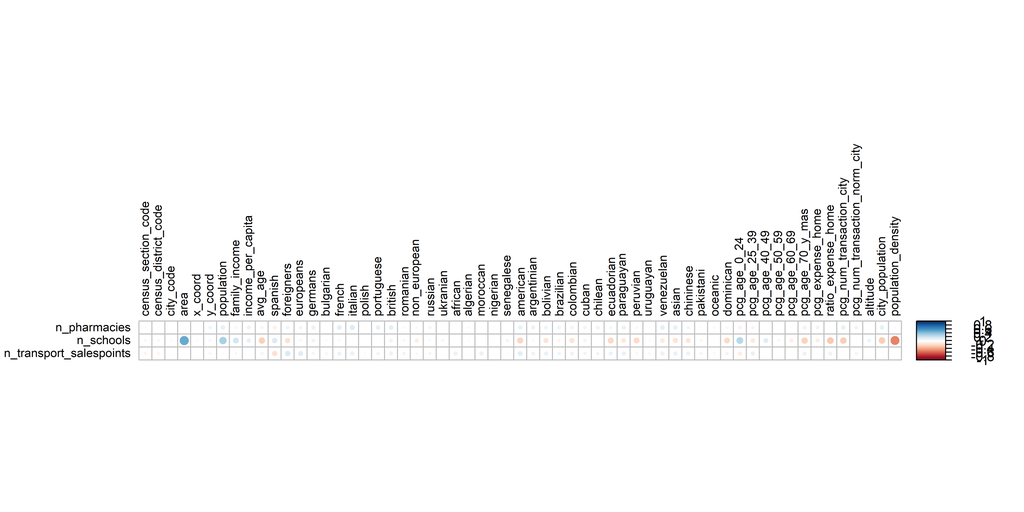

```r
# Using spearman instead of pearson which is better when there are non-linear relationship
cor_matrix <- cor(df[, !names(df) %in% c("n_pharmacies", "n_schools", "n_transport_salespoints")],
                  df[, c("n_pharmacies", "n_schools", "n_transport_salespoints")],
                  method = "spearman")
cor_matrix <- t(cor_matrix)
corrplot(cor_matrix, method = "circle", tl.cex = 0.7, tl.col = "black")
```

Not many explanatory variables seem to be highly correlated with the dependent variables suggesting that the relationship between the dependent variables and independent variables might be non-linear and further strengthening the idea of using a poisson regression model.

Since Spearman correlation seems sometimes stronger than Pearson this suggests that some of the relationship between explanatory variables and dependent variables might be better captured by a monotonic, but non-linear relationship.

# Feature engineering

```r
excluded_vars <- c("n_pharmacies", "n_schools", "n_transport_salespoints")

data <- df %>%
  mutate(across(
    .cols = setdiff(names(df), excluded_vars),
    .fns = list(
      square = ~ .^2,
      cube = ~ .^3,
      sqrt = ~ sqrt(.))))
```

I am transforming our explanatory variables using the square root because many of them present right-skewness and taking the squared root helps tackle this by “compressing” higher values and “stretching” lower values. I chose this over the log transformation because the squared root is able to handle 0s.

I also add squared and cubic transformation so as to model eventual non-linear relationship.

# Feature selection

```r
# Separate target and explanatory variables and pipe them as matrix objects
X <- data |> select(- n_pharmacies, - n_schools, - n_transport_salespoints) |> as.matrix()
Y_pharmacies <- data |> select(n_pharmacies) |> as.matrix()
Y_schools <- data |> select(n_schools) |> as.matrix()
Y_transport <- data |> select(n_transport_salespoints) |> as.matrix()
```

```r
set.seed(123)

# Applying regularization
shrinkage_pharmacies <- cv.glmnet(
  x = X, y = Y_pharmacies,
  lambda = NULL, alpha = 1,
  type.measure = "mse",
  standardize = TRUE,
  nfolds = 10,
  family = "poisson")
```

Lambda sequence is computed by cv.glmnet itself (`lambda = NULL`). `alpha = 1` implies we are doing a Lasso regularization (we have a lot of variables and we are interested in reducing their number). `type.measure = "mse"` means that I am evaluating best lambda based on mean squared error.

```r
# Extract the coefficients at the best lambda
coefficients <- coef(shrinkage_pharmacies, s = shrinkage_pharmacies$lambda.min)

# Identify non-zero coefficients
non_zero_features <- rownames(coefficients)[which(coefficients != 0)]

# Remove the intercept from the list of features
non_zero_features <- non_zero_features[non_zero_features != "(Intercept)"]

# Select all those features for future regression
pharmacies <- data |>
  select(all_of(non_zero_features), n_pharmacies)

str(pharmacies)
```

```
## tibble [4,414 × 67] (S3: tbl_df/tbl/data.frame)
##  $ area                                : num [1:4414] 0.0311 0.0369 0.0317 0.0115 0.0447 ...
##  $ income_per_capita                   : num [1:4414] 12899 10194 7426 9018 8403 ...
##  $ russian                             : num [1:4414] 0 0 0 0 0 0 0 0 0 0 ...
##  $ ukranian                            : num [1:4414] 0 0.009506 0.000558 0.005488 0.002266 ...
##  $ algerian                            : num [1:4414] 0 0.00127 0.00223 0 0 ...
##  $ senegalese                          : num [1:4414] 0 0 0.000558 0 0 ...
##  $ paraguayan                          : num [1:4414] 0.00186 0.00887 0.00446 0.00988 0.00604 ...
##  $ pakistani                           : num [1:4414] 0 0 0.00781 0 0 ...
##  $ oceanic                             : num [1:4414] 0 0 0.00112 0 0 ...
##  $ dominican                           : num [1:4414] 0.01398 0.0038 0.02287 0.00659 0.00755 ...
##  $ population_sqrt                     : num [1:4414] 32.8 39.7 42.3 30.2 36.4 ...
##  $ family_income_cube                  : num [1:4414] 3.10e+13 1.88e+13 1.21e+13 1.19e+13 1.23e+13 ...
##  $ income_per_capita_square            : num [1:4414] 1.66e+08 1.04e+08 5.51e+07 8.13e+07 7.06e+07 ...
##  $ foreigners_sqrt                     : num [1:4414] 0.366 0.473 0.611 0.463 0.286 ...
```

[output cut: 53 more lines]

```r
# Repeat the same for the other dependent variables

# Schools
set.seed(123)
shrinkage_schools <- cv.glmnet(
  x = X, y = Y_schools,
  lambda = NULL, alpha = 1,
  type.measure="mse",
  standardize = TRUE,
  nfolds = 10,
  family = "poisson")
coefficients <- coef(shrinkage_schools, s = shrinkage_schools$lambda.min)
non_zero_features <- rownames(coefficients)[which(coefficients != 0)]
non_zero_features <- non_zero_features[non_zero_features != "(Intercept)"]
schools <- data |>
  select(all_of(non_zero_features), n_schools)
str(schools)
```

```
## tibble [4,414 × 77] (S3: tbl_df/tbl/data.frame)
##  $ area                         : num [1:4414] 0.0311 0.0369 0.0317 0.0115 0.0447 ...
##  $ y_coord                      : num [1:4414] 4475766 4468991 4470484 4469703 4468907 ...
##  $ germans                      : num [1:4414] 0 0 0 0 0 ...
##  $ french                       : num [1:4414] 0.001864 0 0.000558 0 0 ...
##  $ polish                       : num [1:4414] 0 0.00507 0 0.01098 0 ...
##  $ british                      : num [1:4414] 0.000932 0.000634 0.001115 0 0 ...
##  $ non_european                 : num [1:4414] 0.001864 0.010139 0.000558 0.008782 0.002266 ...
##  $ russian                      : num [1:4414] 0 0 0 0 0 0 0 0 0 0 ...
##  $ moroccan                     : num [1:4414] 0.000932 0.032319 0.014501 0.002195 0.007553 ...
##  $ pcg_num_transaction_norm_city: num [1:4414] 74.7 74.7 74.7 74.7 74.7 ...
##  $ population_density           : num [1:4414] 34537 42768 56589 79410 29593 ...
##  $ census_section_code_cube     : num [1:4414] 2.21e+28 2.21e+28 2.21e+28 2.21e+28 2.21e+28 ...
##  $ census_district_code_cube    : num [1:4414] 2.21e+19 2.21e+19 2.21e+19 2.21e+19 2.21e+19 ...
##  $ city_code_cube               : num [1:4414] 2.21e+13 2.21e+13 2.21e+13 2.21e+13 2.21e+13 ...
```

[output cut: 63 more lines]

```r
# Transport
set.seed(123)
shrinkage_transport <- cv.glmnet(
  x = X, y = Y_transport,
  lambda = NULL, alpha = 1,
  type.measure="mse",
  standardize = TRUE,
  nfolds = 10,
  family = "poisson")
coefficients <- coef(shrinkage_transport, s = shrinkage_transport$lambda.min)
non_zero_features <- rownames(coefficients)[which(coefficients != 0)]
non_zero_features <- non_zero_features[non_zero_features != "(Intercept)"]
transport <- data |>
  select(all_of(non_zero_features), n_transport_salespoints)
str(transport)
```

```
## tibble [4,414 × 21] (S3: tbl_df/tbl/data.frame)
##  $ italian                           : num [1:4414] 0.00186 0.00317 0.00223 0.00549 0.00151 ...
##  $ area_sqrt                         : num [1:4414] 0.176 0.192 0.178 0.107 0.212 ...
##  $ population_sqrt                   : num [1:4414] 32.8 39.7 42.3 30.2 36.4 ...
##  $ foreigners_sqrt                   : num [1:4414] 0.366 0.473 0.611 0.463 0.286 ...
##  $ europeans_sqrt                    : num [1:4414] 0.178 0.2803 0.1294 0.2366 0.0824 ...
##  $ french_sqrt                       : num [1:4414] 0.0432 0 0.0236 0 0 ...
##  $ italian_sqrt                      : num [1:4414] 0.0432 0.0563 0.0472 0.0741 0.0389 ...
##  $ british_sqrt                      : num [1:4414] 0.0305 0.0252 0.0334 0 0 ...
##  $ moroccan_square                   : num [1:4414] 8.69e-07 1.04e-03 2.10e-04 4.82e-06 5.70e-05 ...
##  $ moroccan_cube                     : num [1:4414] 8.09e-10 3.38e-05 3.05e-06 1.06e-08 4.31e-07 ...
##  $ venezuelan_sqrt                   : num [1:4414] 0.1058 0.0835 0.0884 0.124 0.055 ...
##  $ chininese_sqrt                    : num [1:4414] 0 0.0712 0.398 0.0812 0.1579 ...
##  $ pakistani_cube                    : num [1:4414] 0.00 0.00 4.76e-07 0.00 0.00 ...
##  $ dominican_square                  : num [1:4414] 1.95e-04 1.45e-05 5.23e-04 4.34e-05 5.70e-05 ...
##  $ dominican_cube                    : num [1:4414] 2.73e-06 5.50e-08 1.20e-05 2.86e-07 4.31e-07 ...
##  $ pcg_age_0_24_cube                 : num [1:4414] 0.00488 0.01248 0.01801 0.01139 0.01479 ...
##  $ pcg_age_70_y_mas_sqrt             : num [1:4414] 0.494 0.417 0.308 0.493 0.37 ...
##  $ pcg_num_transaction_city_cube     : num [1:4414] 1e+06 1e+06 1e+06 1e+06 1e+06 1e+06 1e+06 1e+06 1e+06 1e+06 ...
##  $ pcg_num_transaction_norm_city_sqrt: num [1:4414] 8.64 8.64 8.64 8.64 8.64 ...
##  $ population_density_cube           : num [1:4414] 4.12e+13 7.82e+13 1.81e+14 5.01e+14 2.59e+13 ...
##  $ n_transport_salespoints           : num [1:4414] 1 0 0 0 0 0 1 0 0 0 ...
```

Transport, compared to the other dependent variables, has a relatively low number of relevant features. This might be because it is the target variable with the least variation and hence we might have difficulties in building a linear model for it.

# Regression models

As our dependent variables are non-negative count data we will fit several models. We will fit a linear model, although as a baseline and then try to fit Poisson regression and its variations to see whether they improve the model performance or not.

Since `n_schools` had a variance double its mean we will fit QuasiPoisson and Negative Binomial Regression to take into account potential overdispersion. Furthermore, given that all of the target variables (especially `n_transport_salespoints`) had a high number of zeros, we will fit also a zero-inflated poisson and a zero-inflated negative binomial. Unfortunately we are not able to run cross validation for selecting the best parameters for our model (as some of this model are not supported by `caret`), so each model will be trained only once on the whole training dataframe. We will evaluate all these model on the test dataset using MAE, RMSE and R2, as well as looking at their AIC.

```r
set.seed(1234)

# Splitting data
training_samples <- data$n_pharmacies |>
  createDataPartition(p = 0.8, list = FALSE)

# Creating different datasets for all dependent variables
train_pharmacies  <- pharmacies[training_samples, ]
test_pharmacies <- pharmacies[-training_samples, ]

train_schools  <- schools[training_samples, ]
test_schools <- schools[-training_samples, ]

train_transport  <- transport[training_samples, ]
test_transport <- transport[-training_samples, ]
```

## Pharmacies

```r
set.seed(12345)

# Linear model
lm_pharmacies <- lm(n_pharmacies ~ ., data = train_pharmacies)

# Poisson model
poisson_pharmacies <- glm(n_pharmacies ~ ., data = train_pharmacies, family = "poisson")

# Quasi-Poisson model
qpois_pharmacies <- glm(n_pharmacies ~ ., data = train_pharmacies, family = "quasipoisson")

# Negative Binomial model
negbin_pharmacies <- glm.nb(n_pharmacies ~ ., data = train_pharmacies)
# Zero-Inflated Poisson model
zip_pharmacies <- zeroinfl(n_pharmacies ~ ., data = train_pharmacies, dist="poisson", link = "logit")

# Zero-Inflated Negative Binomial model
zinb_pharmacies <- zeroinfl(n_pharmacies ~ ., data = train_pharmacies, dist="negbin", link = "logit")
```

```r
list(linear = AIC(lm_pharmacies),
     poisson = AIC(poisson_pharmacies),
     quasi_poisson = AIC(qpois_pharmacies),
     negative_binomial = AIC(negbin_pharmacies),
     zero_inflated_poisson = AIC(zip_pharmacies),
     zero_inflated_negativebinomial = AIC(zinb_pharmacies))
```

```
## $linear
## [1] 7235.431
##
## $poisson
## [1] 7036.743
##
## $quasi_poisson
## [1] NA
##
## $negative_binomial
## [1] 7038.798
##
## $zero_inflated_poisson
## [1] 8329.64
##
## $zero_inflated_negativebinomial
## [1] 8107.948
```

AIC unfortunately cannot be calculated for the quasi-poisson. However in the trainig data, the model with the best AIC seems to be the Poisson.

```r
test_pharmacies <- test_pharmacies |>
  mutate(
    pred_lm = predict(lm_pharmacies, test_pharmacies, type = "response"),
    pred_poisson = predict(poisson_pharmacies, test_pharmacies, type = "response"),
    pred_quasip = predict(qpois_pharmacies, test_pharmacies, type = "response"),
    pred_negbin = predict(negbin_pharmacies, test_pharmacies, type = "response"),
    pred_zip = predict(zip_pharmacies, test_pharmacies, type = "response"),
    pred_zinb = predict(zinb_pharmacies, test_pharmacies, type = "response")
)

data.frame(
  model = c("linear", "poisson", "quasi-poisson", "negative-binomial", "zero-inflated-poisson", "zero-inflated-negative-binomial"),
  MAE = c(MAE(test_pharmacies$n_pharmacies, test_pharmacies$pred_lm),
          MAE(test_pharmacies$n_pharmacies, test_pharmacies$pred_poisson),
          MAE(test_pharmacies$n_pharmacies, test_pharmacies$pred_quasip),
          MAE(test_pharmacies$n_pharmacies, test_pharmacies$pred_negbin),
          MAE(test_pharmacies$n_pharmacies, test_pharmacies$pred_zip),
          MAE(test_pharmacies$n_pharmacies, test_pharmacies$pred_zinb)),
    RMSE = c(RMSE(test_pharmacies$n_pharmacies, test_pharmacies$pred_lm),
          RMSE(test_pharmacies$n_pharmacies, test_pharmacies$pred_poisson),
          RMSE(test_pharmacies$n_pharmacies, test_pharmacies$pred_quasip),
          RMSE(test_pharmacies$n_pharmacies, test_pharmacies$pred_negbin),
          RMSE(test_pharmacies$n_pharmacies, test_pharmacies$pred_zip),
          RMSE(test_pharmacies$n_pharmacies, test_pharmacies$pred_zinb)),
    R2 = c(R2(test_pharmacies$n_pharmacies, test_pharmacies$pred_lm),
          R2(test_pharmacies$n_pharmacies, test_pharmacies$pred_poisson),
          R2(test_pharmacies$n_pharmacies, test_pharmacies$pred_quasip),
          R2(test_pharmacies$n_pharmacies, test_pharmacies$pred_negbin),
          R2(test_pharmacies$n_pharmacies, test_pharmacies$pred_zip),
          R2(test_pharmacies$n_pharmacies, test_pharmacies$pred_zinb)))
```

```
##                             model       MAE      RMSE         R2
## 1                          linear 0.5547312 0.6780612 0.09368774
## 2                         poisson 0.5647060 0.6852427 0.08488592
## 3                   quasi-poisson 0.5647060 0.6852427 0.08488592
## 4               negative-binomial 0.5647063 0.6852431 0.08488528
## 5           zero-inflated-poisson 0.5724464 0.7334461 0.07511174
## 6 zero-inflated-negative-binomial 0.5647912 0.7016892 0.08182532
```

Linear model seems to be the best one across all performance scores.

## Schools

```r
set.seed(12345)

# Linear model
lm_schools <- lm(n_schools ~ ., data = train_schools)

# Poisson model
poisson_schools <- glm(n_schools ~ ., data = train_schools, family = "poisson")

# Quasi-Poisson model
qpois_schools <- glm(n_schools ~ ., data = train_schools, family = "quasipoisson")

# Negative Binomial model
negbin_schools <- glm.nb(n_schools ~ ., data = train_schools)

# Zero-Inflated Poisson model
zip_schools <- zeroinfl(n_schools ~ ., data = train_schools, dist="poisson", link = "logit")
# Zero-Inflated Negative Binomial model
zinb_schools <- zeroinfl(n_schools ~ ., data = train_schools, dist="negbin", link = "logit")
list(linear = AIC(lm_schools),
     poisson = AIC(poisson_schools),
     quasi_poisson = AIC(qpois_schools),
     negative_binomial = AIC(negbin_schools),
     zero_inflated_poisson = AIC(zip_schools),
     zero_inflated_negativebinomial = AIC(zinb_schools))
```

```
## $linear
## [1] 11182.01
##
## $poisson
## [1] 8248.504
##
## $quasi_poisson
## [1] NA
##
## $negative_binomial
## [1] 8139.356
##
## $zero_inflated_poisson
## [1] 9116.715
##
## $zero_inflated_negativebinomial
## [1] 9620.872
```

The model with the best AIC in the training data is the negative binomial.

```r
test_schools <- test_schools |>
  mutate(
    pred_lm = predict(lm_schools, test_schools, type = "response"),
    pred_poisson = predict(poisson_schools, test_schools, type = "response"),
    pred_quasip = predict(qpois_schools, test_schools, type = "response"),
    pred_negbin = predict(negbin_schools, test_schools, type= "response"),
    pred_zip = predict(zip_schools, test_schools, type = "response"),
    pred_zinb = predict(zinb_schools, test_schools, type = "response")
)

data.frame(
  model = c("linear", "poisson", "quasi-poisson", "negative-binomial", "zero-inflated-poisson", "zero-inflated-negative-binomial"),
  MAE = c(MAE(test_schools$n_schools, test_schools$pred_lm),
          MAE(test_schools$n_schools, test_schools$pred_poisson),
          MAE(test_schools$n_schools, test_schools$pred_quasip),
          MAE(test_schools$n_schools, test_schools$pred_negbin),
          MAE(test_schools$n_schools, test_schools$pred_zip),
          MAE(test_schools$n_schools, test_schools$pred_zinb)),
    RMSE = c(RMSE(test_schools$n_schools, test_schools$pred_lm),
          RMSE(test_schools$n_schools, test_schools$pred_poisson),
          RMSE(test_schools$n_schools, test_schools$pred_quasip),
          RMSE(test_schools$n_schools, test_schools$pred_negbin),
          RMSE(test_schools$n_schools, test_schools$pred_zip),
          RMSE(test_schools$n_schools, test_schools$pred_zinb)),
    R2 = c(R2(test_schools$n_schools, test_schools$pred_lm),
          R2(test_schools$n_schools, test_schools$pred_poisson),
          R2(test_schools$n_schools, test_schools$pred_quasip),
          R2(test_schools$n_schools, test_schools$pred_negbin),
          R2(test_schools$n_schools, test_schools$pred_zip),
          R2(test_schools$n_schools, test_schools$pred_zinb)))
```

```
##                             model       MAE     RMSE        R2
## 1                          linear 0.8080463 1.107958 0.2451760
## 2                         poisson 0.7615680 1.068603 0.2971241
## 3                   quasi-poisson 0.7615680 1.068603 0.2971241
## 4               negative-binomial 0.7615697 1.067612 0.2983635
## 5           zero-inflated-poisson       Inf      Inf       NaN
## 6 zero-inflated-negative-binomial       Inf      Inf       NaN
```

Negative binomial seems to be better than Poisson and QuasiPoisson, by the slightest of the margins. Although it has a slightly higher MAE, its R-squared is better by a more “decisive” amount than the difference in MAE, and its AIC was better than the Poisson. Furthermore, my choice makes sense, because, as anticipated `n_schools` was the one where overdispersion was the most likely to be a problem.

## Transport Salespoints

```r
set.seed(12345)

# Linear model
lm_transport <- lm(n_transport_salespoints ~ ., data = train_transport)

# Poisson model
poisson_transport <- glm(n_transport_salespoints ~ ., data = train_transport, family = "poisson")

# Quasi-Poisson model
qpois_transport <- glm(n_transport_salespoints ~ ., data = train_transport, family = "quasipoisson")

# Negative Binomial model
negbin_transport <- glm.nb(n_transport_salespoints ~ ., data = train_transport)
# Zero-Inflated Poisson model
zip_transport <- zeroinfl(n_transport_salespoints ~ ., data = train_transport, dist="poisson", link = "logit")
# Zero-Inflated Negative Binomial model
zinb_transport <- zeroinfl(n_transport_salespoints ~ ., data = train_transport, dist="negbin", link = "logit")
list(linear = AIC(lm_transport),
     poisson = AIC(poisson_transport),
     quasi_poisson = AIC(qpois_transport),
     negative_binomial = AIC(negbin_transport),
     zero_inflated_poisson = AIC(zip_transport),
     zero_inflated_negativebinomial = AIC(zinb_transport))
```

```
## $linear
## [1] 5069.262
##
## $poisson
## [1] 4319.946
##
## $quasi_poisson
## [1] NA
##
## $negative_binomial
## [1] 4321.98
##
## $zero_inflated_poisson
## [1] 4428.128
##
## $zero_inflated_negativebinomial
## [1] 4343.579
```

The model with the best AIC in the training data is the Poisson.

```r
test_transport <- test_transport |>
  mutate(
    pred_lm = predict(lm_transport, test_transport, type = "response"),
    pred_poisson = predict(poisson_transport, test_transport, type = "response"),
    pred_quasip = predict(qpois_transport, test_transport, type = "response"),
    pred_negbin = predict(negbin_transport, test_transport, type= "response"),
    pred_zip = predict(zip_transport, test_transport, type = "response"),
    pred_zinb = predict(zinb_transport, test_transport, type = "response")
)

data.frame(
  model = c("linear", "poisson", "quasi-poisson", "negative-binomial", "zero-inflated-poisson", "zero-inflated-negative-binomial"),
  MAE = c(MAE(test_transport$n_transport_salespoints, test_transport$pred_lm),
          MAE(test_transport$n_transport_salespoints, test_transport$pred_poisson),
          MAE(test_transport$n_transport_salespoints, test_transport$pred_quasip),
          MAE(test_transport$n_transport_salespoints, test_transport$pred_negbin),
          MAE(test_transport$n_transport_salespoints, test_transport$pred_zip),
          MAE(test_transport$n_transport_salespoints, test_transport$pred_zinb)),
    RMSE = c(RMSE(test_transport$n_transport_salespoints, test_transport$pred_lm),
          RMSE(test_transport$n_transport_salespoints, test_transport$pred_poisson),
          RMSE(test_transport$n_transport_salespoints, test_transport$pred_quasip),
          RMSE(test_transport$n_transport_salespoints, test_transport$pred_negbin),
          RMSE(test_transport$n_transport_salespoints, test_transport$pred_zip),
          RMSE(test_transport$n_transport_salespoints, test_transport$pred_zinb)),
    R2 = c(R2(test_transport$n_transport_salespoints, test_transport$pred_lm),
          R2(test_transport$n_transport_salespoints, test_transport$pred_poisson),
          R2(test_transport$n_transport_salespoints, test_transport$pred_quasip),
          R2(test_transport$n_transport_salespoints, test_transport$pred_negbin),
          R2(test_transport$n_transport_salespoints, test_transport$pred_zip),
          R2(test_transport$n_transport_salespoints, test_transport$pred_zinb)))
```

```
##                             model       MAE      RMSE        R2
## 1                          linear 0.3682705 0.4766986 0.1021371
## 2                         poisson 0.3617004 0.4726727 0.1173170
## 3                   quasi-poisson 0.3617004 0.4726727 0.1173170
## 4               negative-binomial 0.3617003 0.4726727 0.1173169
## 5           zero-inflated-poisson 0.3529748 0.4738128 0.1186867
## 6 zero-inflated-negative-binomial 0.3612235 0.4727477 0.1171113
```

Zero Inflated Poisson seems to be the best one, it has a slightly higher R2 and a slightly lower mean absolute error, even if its RMSE is a bit higher. Given the high number of zeros present in `n_transport_salespoints` I’ll opt for the zero-inflated Poisson.

# Score generation

```r
set.seed(123456)

# Train again on the whole dataset
model_pharmacies <- lm(n_pharmacies ~ ., data = pharmacies)
model_schools <- glm.nb(n_schools ~ ., data = schools)
model_transport <- zeroinfl(n_transport_salespoints ~ ., data = transport, dist="poisson", link = "logit")
# Predict
prediction_pharmacies <- predict(model_pharmacies, pharmacies, type = "response") |>  as.vector()
prediction_schools <- predict(model_schools, schools, type = "response") |>  as.vector()
prediction_transport <- predict(model_transport, transport, type = "response") |>  as.vector()
```

After having selected the best model type for each dependent variables, I train again that model, but now using the whole dataset (training + test). Hopefully, having more training data will yield us better results when using the models to predict our target variables. We will then use these predictions to create a score.

```r
# Generate score
score <- df |>
  mutate(score_pharmacies = round(prediction_pharmacies),
         score_schools = round(prediction_schools),
         score_transport = round(prediction_transport),
         lack_facilities = as.factor(case_when(
           score_pharmacies > n_pharmacies & score_schools > n_schools & score_transport > n_transport_salespoints ~ "Severe",
           (score_pharmacies > n_pharmacies & score_schools > n_schools & score_transport <= n_transport_salespoints) |
             (score_pharmacies > n_pharmacies & score_schools <= n_schools & score_transport > n_transport_salespoints) |
             (score_pharmacies <= n_pharmacies & score_schools > n_schools & score_transport > n_transport_salespoints) ~ "Moderate",
           (score_pharmacies > n_pharmacies & score_schools <= n_schools & score_transport <= n_transport_salespoints) |
             (score_pharmacies <= n_pharmacies & score_schools > n_schools & score_transport <= n_transport_salespoints) |
             (score_pharmacies <= n_pharmacies & score_schools <= n_schools & score_transport > n_transport_salespoints) ~ "Mild",
           TRUE ~ "No"
         )),
         lack_facilities_binary = as.factor(ifelse(lack_facilities %in% c("Severe", "Moderate", "Mild"), "Yes", "No")))
```

I round the predictions of our model to create the supposed number of facilities that our model suggests. If the data shows that the actual number of any of those facilities is below the suggested predicted number of facilities that census section will be considered as lacking facilites.

```r
set.seed(1234567)

# Organize dataframes
log_df <- score |>
  select(-score_pharmacies, -score_schools, -score_transport, -n_pharmacies, -n_schools, -n_transport_salespoints)

log_df_predictors <- log_df |>
  select(-lack_facilities, -lack_facilities_binary) |> as.matrix()

log_df_target <- log_df |>
  select(lack_facilities_binary) |> as.matrix()

# Apply Lasso regularization to logistic
shrinkage_logistic <- cv.glmnet(
  x = log_df_predictors, y = log_df_target,
  lambda = NULL, alpha = 1,
  type.measure = "auc",
  standardize = TRUE,
  nfolds = 10,
  family = "binomial")

# Predictions
pred_prob <- predict(shrinkage_logistic, s = "lambda.min", log_df_predictors, type = "response")
pred <- predict(shrinkage_logistic, s = "lambda.min", log_df_predictors, type = "class")

# Model results
confusionMatrix(log_df$lack_facilities_binary, as.factor(pred), positive = "Yes")
```

```
## Confusion Matrix and Statistics
##
##           Reference
## Prediction   No  Yes
##        No  1265  906
##        Yes  727 1516
##
##                Accuracy : 0.63
##                  95% CI : (0.6156, 0.6443)
##     No Information Rate : 0.5487
##     P-Value [Acc > NIR] : < 2.2e-16
##
##                   Kappa : 0.2589
##
##  Mcnemar's Test P-Value : 1.059e-05
##
##             Sensitivity : 0.6259
##             Specificity : 0.6350
##          Pos Pred Value : 0.6759
##          Neg Pred Value : 0.5827
##              Prevalence : 0.5487
##          Detection Rate : 0.3435
##    Detection Prevalence : 0.5082
##       Balanced Accuracy : 0.6305
##
##        'Positive' Class : Yes
##
```

```r
auc(log_df$lack_facilities_binary, factor(pred, ordered = T))
```

```
## Area under the curve: 0.6293
```

After having created my score, I try to predict it through a penalized logistic regression with hyperparameter tuning through 10-fold cross validation.

Although my model is significant and the AUC of the logistic prediction is >0.5, the AUC it is actually not really high and the model has an accuracy of 0.63, indicating that it is far from being a perfect model.

# Results analysis and discussion

```r
ftable(factor(log_df$lack_facilities, ordered = T, levels = c("No", "Mild", "Moderate", "Severe")), factor(pred, ordered = T))
```

```
##             No  Yes
##
## No        1265  906
## Mild       663 1149
## Moderate    64  347
## Severe       0   20
```

We successfully predict all cases of severe facility shortages, indicating that we, at least, can accurately identify areas with the most acute issues. However, we face greater challenges in predicting mild and no categories.

In the case that we are worried of predicting too many areas as “lacking facilities” and we are interested in identifying only those with more severe conditions we should increase the threshold for predicting yes, bringing it above 0.5.

We have previously performed regularization and selected only relevant explanatory variables (from the original dataframe), I now train another logistic model on the whole dataset to see which variables are most important.

```r
# Extract the coefficients at the best lambda
coefficients <- coef(shrinkage_logistic, s = shrinkage_logistic$lambda.min)

# Identify non-zero coefficients
non_zero_features <- rownames(coefficients)[which(coefficients != 0)]

# Remove the intercept from the list of features
non_zero_features <- non_zero_features[non_zero_features != "(Intercept)"]

# Select all those features and scale them
log_df <- log_df |>
  select(all_of(non_zero_features), lack_facilities, lack_facilities_binary) |>
  mutate(across(all_of(non_zero_features), scale)) |>
  # Dropping it to handle perfect multicollinearity
  select(-spanish)

# Train the logistic regression on the whole model using caret
final_logistic <- glm(lack_facilities_binary ~ ., data = log_df |> select(-lack_facilities), family = binomial)

# View the trained model
options(scipen = 999)
summary(final_logistic)
```

```
##
## Call:
## glm(formula = lack_facilities_binary ~ ., family = binomial,
##     data = select(log_df, -lack_facilities))
##
## Coefficients:
##                          Estimate Std. Error z value             Pr(>|z|)
## (Intercept)               0.02942    0.03179   0.925             0.354743
## population                0.33753    0.04403   7.666   0.0000000000000177 ***
## income_per_capita         0.01698    0.05608   0.303             0.762009
## foreigners                0.11321    0.05486   2.064             0.039052 *
## bulgarian                 0.06127    0.03695   1.658             0.097299 .
## french                    0.02548    0.04654   0.547             0.584058
## italian                   0.07030    0.04683   1.501             0.133324
## british                   0.02149    0.04552   0.472             0.636931
## chilean                   0.03508    0.03320   1.057             0.290737
## uruguayan                -0.06490    0.03308  -1.962             0.049780 *
## asian                     0.03851    0.04210   0.915             0.360300
## pakistani                 0.04613    0.03514   1.313             0.189319
## oceanic                   0.03680    0.03380   1.089             0.276367
## pcg_age_0_24             -0.20808    0.05596  -3.718             0.000201 ***
## pcg_age_70_y_mas          0.06548    0.05476   1.196             0.231764
## ratio_expense_home       -0.08155    0.05111  -1.595             0.110604
## pcg_num_transaction_city  0.10993    0.03921   2.804             0.005053 **
## city_population           0.20519    0.04282   4.792   0.0000016531327300 ***
## population_density       -0.66552    0.04438 -14.995 < 0.0000000000000002 ***
## ---
## Signif. codes:  0 '***' 0.001 '**' 0.01 '*' 0.05 '.' 0.1 ' ' 1
##
## (Dispersion parameter for binomial family taken to be 1)
##
##     Null deviance: 6117.9  on 4413  degrees of freedom
## Residual deviance: 5656.8  on 4395  degrees of freedom
## AIC: 5694.8
##
## Number of Fisher Scoring iterations: 4
```

The most statistically significant variables are `population`, `pcg_age_0_24`, `city_population` and `population_density`. `population` and `city_population` have a positive coefficient meaning that higher population implies more likelihood of lacking facilities. `population_density` and `pcg_age_0_24` instead have a negative coefficient thus implying that more densely populated area or areas with a higher population of young people are less likely to lack facilities.

These variables seem plausible as area with more people need more facilities and thus it might be more probable that the authorities are not able to provide as many facilities as needed for that many people. Furthermore, it is unfortunately true that areas with a higher percentages of foreigners often lack basic facilities.

The fact that some of the most relevant variables (in our final logistic) are coded at a city level, and the fact that (I assume) those facilities are provided by municipalities suggests us that a Poisson GLMM with random and fixed effect with city as the grouping variable, could potentially fit the target variables better and thus could help us improve our score and our predictions of which areas lack facilities.

Lastly, it is worth nothing that although heavy multicollinearity and sometimes perfect multicollinarity was detected among our independent variables, I have not tackled the problem as I was more focused on building a predictive model, but this issue needs to be addressed in the case we aim to build a better explanatory model.